# A Bird’s Eye View of the Stock Market

Tom Pedersen

2022-01-12

# Introduction

The aim of this article is to use data from twitter in order to visualize how the sentiment of a handful of listed companies changes over time. We will use unique identifiers, called cashtags, in order to download tweets talking about specific companies and use lexicon based sentiment analysis. The main goal is to visualize how the sentiment of an individual company is changing relative to others, in a graph inspired by the [Relative Rotation Graph](https://www.relativerotationgraphs.com)*.

*DISCLAIMER: This article is not to be seen as investment advise. The author of this article leaves no guarantee for the correctness or completeness of the information in this article. *“Relative Rotation Graph” and “RRG” are registered trademarks of RRG Research.*

# Data aqcuisution

Below is a brief overview of data used and how it was obtained:

- The list of twitter feeds investors were scraped of the website [Investopedia](https://www.investopedia.com/financial-edge/0712/10-twitter-feeds-investors-should-follow.aspx) using the R package `rvest`,
- Tweets and information about twitter users were collected using the Twitter API trough the R package `rtweet`,
- The sentiment/emotion lexicon was downloaded from the [National Research Council Canada](https://saifmohammad.com/WebPages/NRC-Emotion-Lexicon.htm),
- Stock market data was downloaded through the Yahoo Finance API using the R package `httr`.

## Twitter data - quality over quantity?

It is particularity hard to quantify the sentiment of a 280-character tweet. An attempt at getting higher quality data could be to only look at timelines of influential and relevant twitter users. Below is a table of the top 10 twitter feeds investors from [investopedia](https://www.investopedia.com/financial-edge/0712/10-twitter-feeds-investors-should-follow.aspx), which could be used to carry out sentiment analysis. However, one drawback of this approach is that we are limited to the companies discussed by these users.

Top 10 twitter feeds investors according to Investopeida

| screen name | location | followers | number of tweets |
| --- | --- | --- | --- |
| CNBC | Englewood Cliffs, NJ | 4465211 | 472819 |
| Stocktwits | New York, NY | 940829 | 50710 |
| nytimesbusiness | New York, NY | 832645 | 240785 |
| WSJmarkets | New York, NY | 738669 | 83573 |
| IBDinvestors | Los Angeles, CA | 266441 | 85677 |
| Benzinga | Downtown Detroit, MI & NYC | 224699 | 173697 |
| bespokeinvest | Harrison, New York | 134273 | 39266 |
| BreakoutStocks | Silicon Valley, CA | 86585 | 36766 |
| WSJDealJournal | New York, NY | 8824 | 1 |
| Stephanie | Middelburg, The Netherlands | 1549 | 10117 |

## Eyes on the money - $cashtags

Another approach, and the one we will use, is to utilize $cashtags in order to get twitter data about the companies we’re interested in. These are unique identifiers generally based on abbreviations of listed companies (much like [ticker symbols](https://en.wikipedia.org/wiki/Ticker_symbol)) used for tagging, i.e. the hashtag of finance.

We will look at seven giant tech companies: Apple, Alphabet (Google), Microsoft, Amazon, Netflix, Meta (Facebook) and Twitter. These companies have the following cashtags, respectively: $AAPL, $GOOGL, $MSFT, $AMZN, $NFLX, $FB and $TWTR.

Unfortunately, a query to the twitter API doesn’t allow us to specify a time/date interval and will return tweets created in an arbitrary time period, at most about one week old. As a consequence, I was not able to get data in the same time frame for all companies. The distribution of the tweets is visualized in the plot below.

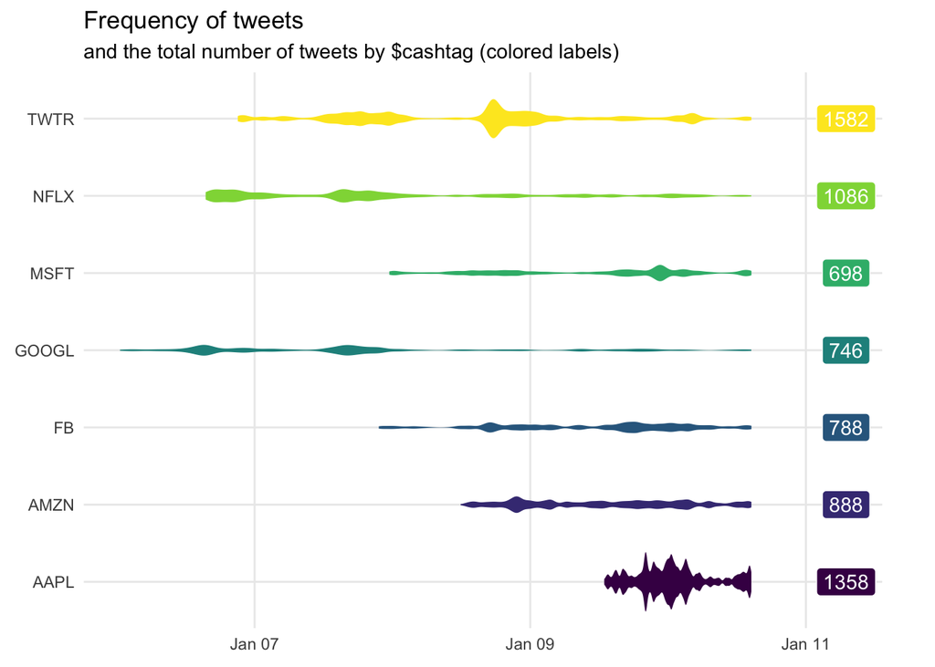

As seen, both the range and total numbers of tweets vary greatly between our companies.

# Data visualizations

## Head in the wordcloud

A flaw with lexicon based sentiment analysis is the loss of context, since every word is treated individually. Therefore, we will explore the frequency of emotional keywords in the twitter data using a word-cloud in an attempt to detect any fragility in the future analysis.

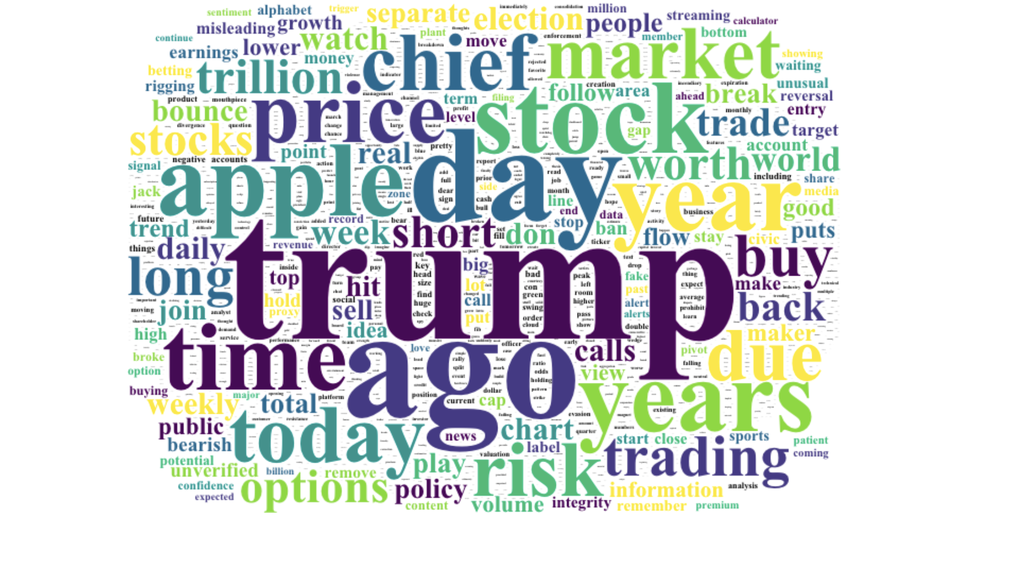

Two emotional keywords that probably catch your eyes are ‘trump’ and ‘apple’. While the verb ‘trump’ probably has positive connotations for a card player, I suspect that most tweets talking about ‘trump’ are referring to the controversial former president Donald Trump. Another problematic keyword is ‘apple’. It’s not surprising that it is one of the most occurring words since we have downloaded tweets talking about the biggest tech company on earth, but our lexicon is probably referring to the fruit. These keywords are removed from the lexicon from here on and out.

## Emotions are not one-dimensional

While the main focus of this article is the positive/negative sentiment of tweets, we will take a brief look at some other emotional keywords they contain. Below is a plot with the proportion of ten unique emotions (grouped by cashtag/company).

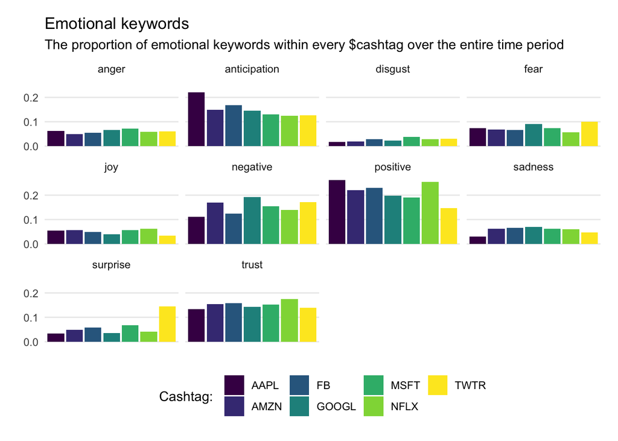

## Sentiment and smoooothing

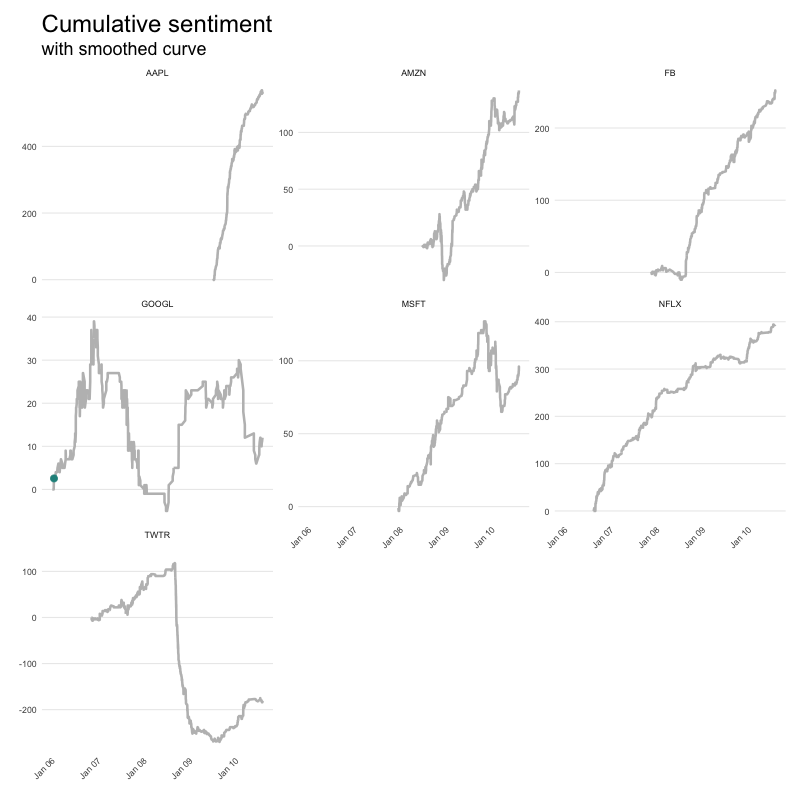

## Relative Rotation Graph

Now that we’ve calculated the sentiment based on our tweets, it’s time to create the Relative Rotation Graph. The horizontal axis is the relative sentiment, where the sentiment of each company is compared to the total mean sentiment of all companies. The vertical axis is the rate of change of the relative sentiment, i.e. how fast the relative sentiment is changing and if it’s decreasing or increasing. The axes are centered around 100 for computational purposes*.

*The axes are centered around 100 in order to avoid division by zero when calculating the rate of change, since the relative sentiment could equal zero otherwise.

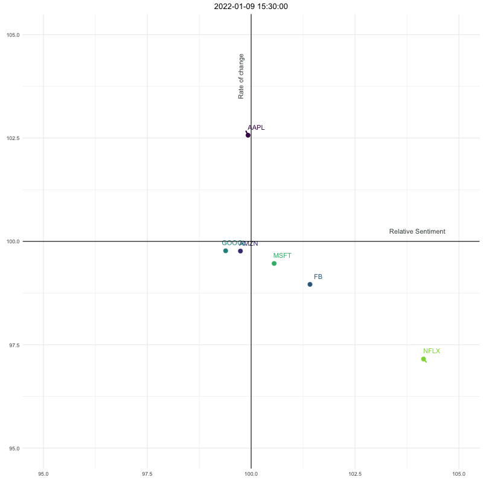

Twitter (the company) starts with the weakest relative sentiment but also makes the biggest positive change due to its high positive rate of change. Apple’s relative sentiment starts in the middle with a high positive rate of change, which pushes Apple to have the highest relative sentiment at the end. Note, however, that Apple’s rate of change turns negative at the end. Furthermore, Netflix starts with the highest relative sentiment but due to its high negative rate of change looses to Apple at the end.

## A double outlook into the future

While I guarantee no correctness or completeness of the Relative Rotation Graph or the data it’s based on, the future aim of the graph is to aid in investment decision making. Therefore, I end this article by presenting how the pertinent stocks performed on January 10, 14:30-19:30 (the last frame of the Relative Rotation Graph is at January 10, 15:30). Before you take a look at how the stocks performed - what would be your investment be based on the Relative Rotation Graph?

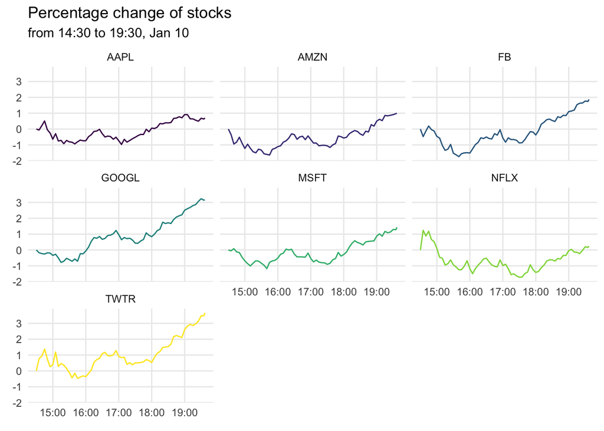

# Summary and some comments

Using twitter as a basis for sentiment analysis proved a challenge. Not only are there limitations to using the free version of the Twitter API, but the data obtained is messy and filled with tweets from bots (low quality with regards to sentiment analysis). One way I handled bots were to filter the data for tweets containing no more than a single cashtag, since bots have a tendency to tag several companies per tweet. This method also got rid of some ambiguity since a single cashtag probably means that the tweet is more relevant to the company we’re interested in.

Given the challenges I am quite pleased with how the Relative Rotation Graph turned out even though I see a lot of room for improvement. Due to the limitations of the Twitter API I had to use a much shorter time window than I wanted. I think that the Relative Rotation Graph is more suited for data over longer periods of time where longer trends can be compared. Due to the short time window I had to use a lot of smoothing in order for the graph to not be a complete mess.

Another improvement that could be made is to use more sophisticated models for sentiment analysis, like machine learning models. One could also use [n-grams](https://en.wikipedia.org/wiki/N-gram) to capture textual context or more specific emotion/sentiment lexicons that are suited for twitter and/or financial jargon.